# `The TASK1`

`简介:` DW第21期数据分析方向--目标15天内完成小型论文分析项目  
`目标:` 论⽂文数量量统计（数据统计任务）：统计2019年年全年年，计算机各个⽅方向论⽂文数量量；  
`数据集:` https://www.kaggle.com/Cornell-University/arxiv

> 数据集的格式如下：
> - id：arXiv ID，可⽤用于访问论⽂文；
> - submitter：论⽂文提交者；
> - authors：论⽂文作者；
> - title：论⽂文标题；
> - comments：论⽂文⻚页数和图表等其他信息；
> - journal-ref：论⽂文发表的期刊的信息；
> - doi：数字对象标识符，https://www.doi.org；
> - report-no：报告编号；
> - categories：论⽂文在 arXiv 系统的所属类别或标签；
> - license：⽂文章的许可证；
> - abstract：论⽂文摘要；
> - versions：论⽂文版本；
> - authors_parsed：作者的信息。

## 任务1搭建环境

```python
import seaborn as sns #⽤用于画图
from bs4 import BeautifulSoup #⽤用于爬取arxiv的数据
import re #⽤用于正则表达式，匹配字符串串的模式
import requests #⽤用于⽹网络连接，发送⽹网络请求，使⽤用域名获取对应信息
import json #读取数据，我们的数据为json格式的
import pandas as pd #数据处理理，数据分析
import matplotlib.pyplot as plt #画图⼯工具
import os #读取文件
```

```python
data  = [] #初始化
#使⽤用with语句句优势：1.自动关闭文件句句柄；2.自动显示（处理理）文件读取数据异常
with open("arxiv-metadata-oai-snapshot.json", 'r') as f:
    for line in f:
        data.append(json.loads(line))

data = pd.DataFrame(data) #将list变为dataframe格式，方便使用pandas进⾏分析
data.shape #显示数据⼤⼩
```

```
(1796911, 14)
```

## 任务2数据处理

> 1. 筛选出2019年及后的论文
> 2. 从arxiv网站上爬取门类信息,填补原有data表

```python
#双重循环的列表推导器读取每类科目
#set()去重
unique_categories = set([i for l in [x.split(' ') for x in data["categories"]] for i in l])
len(unique_categories), unique_categories
#查看数据
```

```
(176,
 {'acc-phys',
  'adap-org',
  'alg-geom',
  'ao-sci',
  'astro-ph',
  'astro-ph.CO',
  'astro-ph.EP',
  'astro-ph.GA',
  'astro-ph.HE',
  'astro-ph.IM',
  'astro-ph.SR',
  'atom-ph',
  'bayes-an',
  'chao-dyn',
  'chem-ph',
  'cmp-lg',
  'comp-gas',
  'cond-mat',
  'cond-mat.dis-nn',
  'cond-mat.mes-hall',
  'cond-mat.mtrl-sci',
  'cond-mat.other',
  'cond-mat.quant-gas',
  'cond-mat.soft',
  'cond-mat.stat-mech',
  'cond-mat.str-el',
  'cond-mat.supr-con',
  'cs.AI',
  'cs.AR',
  'cs.CC',
  'cs.CE',
  'cs.CG',
  'cs.CL',
  'cs.CR',
  'cs.CV',
  'cs.CY',
  'cs.DB',
  'cs.DC',
  'cs.DL',
```

[output cut: 122 more lines]

```
  'q-fin.MF',
  'q-fin.PM',
  'q-fin.PR',
  'q-fin.RM',
  'q-fin.ST',
  'q-fin.TR',
  'quant-ph',
  'solv-int',
  'stat.AP',
  'stat.CO',
  'stat.ME',
  'stat.ML',
  'stat.OT',
  'stat.TH',
  'supr-con'})
```

```python
data["year"] = pd.to_datetime(data["update_date"]).dt.year
#将update_date从str变为datetime格式，并提取处year
del data["update_date"]
#删除 update_date特征，其使命已完成
data = data[data["year"] >= 2019]
#找出 year 中2019年年以后的数据，并将其他数据覆盖
data.groupby(['categories','year'])
#以 categories 进⾏行行排序，如果同⼀一个categories 相同则使⽤用 year 特征进⾏行行排序
data.reset_index(drop=True, inplace=True) #重新编号
data #查看结果
```

|  | id | submitter | authors | title | comments | journal-ref | doi | report-no | categories | license | abstract | versions | authors_parsed | year |
| --- | --- | --- | --- | --- | --- | --- | --- | --- | --- | --- | --- | --- | --- | --- |
| 0 | 0704.0297 | Sung-Chul Yoon | Sung-Chul Yoon, Philipp Podsiadlowski and Step... | Remnant evolution after a carbon-oxygen white ... | 15 pages, 15 figures, 3 tables, submitted to M... | None | 10.1111/j.1365-2966.2007.12161.x | None | astro-ph | None | We systematically explore the evolution of t... | [{'version': 'v1', 'created': 'Tue, 3 Apr 2007... | [[Yoon, Sung-Chul, ], [Podsiadlowski, Philipp,... | 2019 |
| 1 | 0704.0342 | Patrice Ntumba Pungu | B. Dugmore and PP. Ntumba | Cofibrations in the Category of Frolicher Spac... | 27 pages | None | None | None | math.AT | None | Cofibrations are defined in the category of ... | [{'version': 'v1', 'created': 'Tue, 3 Apr 2007... | [[Dugmore, B., ], [Ntumba, PP., ]] | 2019 |
| 2 | 0704.0360 | Zaqarashvili | T.V. Zaqarashvili and K Murawski | Torsional oscillations of longitudinally inhom... | 6 pages, 3 figures, accepted in A&A | None | 10.1051/0004-6361:20077246 | None | astro-ph | None | We explore the effect of an inhomogeneous ma... | [{'version': 'v1', 'created': 'Tue, 3 Apr 2007... | [[Zaqarashvili, T. V., ], [Murawski, K, ]] | 2019 |
| 3 | 0704.0525 | Sezgin Ayg\"un | Sezgin Aygun, Ismail Tarhan, Husnu Baysal | On the Energy-Momentum Problem in Static Einst... | This submission has been withdrawn by arXiv ad... | Chin.Phys.Lett.24:355-358,2007 | 10.1088/0256-307X/24/2/015 | None | gr-qc | None | This paper has been removed by arXiv adminis... | [{'version': 'v1', 'created': 'Wed, 4 Apr 2007... | [[Aygun, Sezgin, ], [Tarhan, Ismail, ], [Baysa... | 2019 |
| 4 | 0704.0535 | Antonio Pipino | Antonio Pipino (1,3), Thomas H. Puzia (2,4), a... | The Formation of Globular Cluster Systems in M... | 32 pages (referee format), 9 figures, ApJ acce... | Astrophys.J.665:295-305,2007 | 10.1086/519546 | None | astro-ph | None | The most massive elliptical galaxies show a ... | [{'version': 'v1', 'created': 'Wed, 4 Apr 2007... | [[Pipino, Antonio, ], [Puzia, Thomas H., ], [M... | 2019 |
| ... | ... | ... | ... | ... | ... | ... | ... | ... | ... | ... | ... | ... | ... | ... |
| 395118 | quant-ph/9911051 | Stephen A. Fulling | S. A. Fulling | Large Numbers, the Chinese Remainder Theorem, ... | 9 pages; Plain TeX with vanilla.sty and pictex... | Phys. Rev. Applied 13, 024016 (2020) | 10.1103/PhysRevApplied.13.024016 | None | quant-ph | None | This is a pedagogical article cited in the f... | [{'version': 'v1', 'created': 'Thu, 11 Nov 199... | [[Fulling, S. A., ]] | 2020 |
| 395119 | solv-int/9511005 | Wen-Xiu Ma | Wen-Xiu Ma, Benno Fuchssteiner | Explicit and Exact Solutions to a Kolmogorov-P... | 14pages, Latex, to appear in Intern. J. Nonlin... | None | 10.1016/0020-7462(95)00064-X | None | solv-int nlin.SI | None | Some explicit traveling wave solutions to a ... | [{'version': 'v1', 'created': 'Tue, 14 Nov 199... | [[Ma, Wen-Xiu, ], [Fuchssteiner, Benno, ]] | 2019 |
| 395120 | solv-int/9809008 | Victor Enolskii | J C Eilbeck, V Z Enol'skii, V B Kuznetsov, D V... | Linear r-Matrix Algebra for a Hierarchy of One... | plain LaTeX, 28 pages | None | None | None | solv-int nlin.SI | None | We consider a hierarchy of many-particle sys... | [{'version': 'v1', 'created': 'Wed, 2 Sep 1998... | [[Eilbeck, J C, ], [Enol'skii, V Z, ], [Kuznet... | 2019 |
| 395121 | solv-int/9909010 | Pierre van Moerbeke | M. Adler, T. Shiota and P. van Moerbeke | Pfaff tau-functions | 42 pages | None | None | None | solv-int adap-org hep-th nlin.AO nlin.SI | None | Consider the evolution $$ \frac{\pl m_\iy}{\... | [{'version': 'v1', 'created': 'Wed, 15 Sep 199... | [[Adler, M., ], [Shiota, T., ], [van Moerbeke,... | 2019 |
| 395122 | solv-int/9909014 | David Fairlie | D.B. Fairlie and A.N. Leznov | The General Solution of the Complex Monge-Amp\... | 13 pages, latex, no figures | None | 10.1088/0305-4470/33/25/307 | None | solv-int nlin.SI | None | A general solution to the Complex Monge-Amp\... | [{'version': 'v1', 'created': 'Thu, 16 Sep 199... | [[Fairlie, D. B., ], [Leznov, A. N., ]] | 2019 |

395123 rows × 14 columns

> 爬取页面源代码

```python
# txt = ""
# path = ".\html1.txt"
# f = open(path,encoding='utf-8')
# txt = f.read()
# f.close()

website_url = requests.get('https://arxiv.org/category_taxonomy').text #获取⽹网⻚页 的⽂文本数据
soup = BeautifulSoup(txt,'lxml') #爬取数据，这⾥里里使⽤用lxml的解析器器，加速
```

- **对于难以访问外网的状况提供以下解决措施**

```
#由于arxiv很难访问,因此将网页源代码粘贴到html1.txt
#读取已保存的网页,效率更高
txt = ""
path = ".\html1.txt"
f = open(path,encoding='utf-8')
txt = f.read()
f.close()
```

```python
# soup #检查爬取过来的数据
```

> 对源代码进行整理,提取出所需列表

```python
root = soup.find('div',{'id':'category_taxonomy_list'}) #找出 BeautifulSoup 对应 的标签⼊入⼝口
tags = root.find_all(["h2","h3","h4","p"], recursive=True) #读取 tags

#初始化 str 和 list 变量量
level_1_name = ""
level_2_name = ""
level_2_code = ""
level_1_names = []
level_2_codes = []
level_2_names = []
level_3_codes = []
level_3_names = []
level_3_notes = []

#进⾏行行
for t in tags:
    if t.name == "h2":
        level_1_name = t.text
        level_2_code = t.text
        level_2_name = t.text
    elif t.name == "h3":
        raw = t.text
        level_2_code = re.sub(r"(.*)\((.*)\)",r"\2",raw) #正则表达式：模式字符串串： (.*)\((.*)\)；被替换字符串串"\2"；被处理理字符串串：raw
        level_2_name = re.sub(r"(.*)\((.*)\)",r"\1",raw)
    elif t.name == "h4":
        raw = t.text
        level_3_code = re.sub(r"(.*) \((.*)\)",r"\1",raw)
        level_3_name = re.sub(r"(.*) \((.*)\)",r"\2",raw)
    elif t.name == "p":
        notes = t.text
        level_1_names.append(level_1_name)
        level_2_names.append(level_2_name)
        level_2_codes.append(level_2_code)
        level_3_names.append(level_3_name)
        level_3_codes.append(level_3_code)
        level_3_notes.append(notes)

#根据以上信息⽣生成dataframe格式的数据
df_taxonomy = pd.DataFrame({
    'group_name' : level_1_names,
    'archive_name' : level_2_names,
    'archive_id' : level_2_codes,
    'category_name' : level_3_names,
    'categories' : level_3_codes,
    'category_description': level_3_notes
})

df_taxonomy.groupby(["group_name","archive_name"])
df_taxonomy
```

|  | group_name | archive_name | archive_id | category_name | categories | category_description |
| --- | --- | --- | --- | --- | --- | --- |
| 0 | Computer Science | Computer Science | Computer Science | Artificial Intelligence | cs.AI | Covers all areas of AI except Vision, \nRoboti... |
| 1 | Computer Science | Computer Science | Computer Science | Hardware Architecture | cs.AR | Covers systems organization and hardware archi... |
| 2 | Computer Science | Computer Science | Computer Science | Computational Complexity | cs.CC | Covers models of computation, \ncomplexity cla... |
| 3 | Computer Science | Computer Science | Computer Science | Computational Engineering, Finance, and Science | cs.CE | Covers applications of computer science\n to t... |
| 4 | Computer Science | Computer Science | Computer Science | Computational Geometry | cs.CG | Roughly includes material in ACM Subject Class... |
| ... | ... | ... | ... | ... | ... | ... |
| 150 | Statistics | Statistics | Statistics | Computation | stat.CO | Algorithms, Simulation, Visualization |
| 151 | Statistics | Statistics | Statistics | Methodology | stat.ME | Design, Surveys, Model Selection, \nMultiple T... |
| 152 | Statistics | Statistics | Statistics | Machine Learning | stat.ML | Covers machine learning papers \n(supervised, ... |
| 153 | Statistics | Statistics | Statistics | Other Statistics | stat.OT | Work in statistics that does not fit into the ... |
| 154 | Statistics | Statistics | Statistics | Statistics Theory | stat.TH | stat.TH is an alias for math.ST. Asymptotics, ... |

155 rows × 6 columns

> ```
> - df_taxonomy表和data表合并,以data表为主
> - 去除重复id以及组名
> - 再以组名分类计数
> ```

```python
_df = data.merge(df_taxonomy, on='categories', how='left').drop_duplicates(['id', "group_name"]).groupby('group_name').agg({'id':'count'}).sort_values(by="id", ascending=False).reset_index()
_df['count'] = _df['id']
del _df['id']

_df
```

|  | group_name | count |
| --- | --- | --- |
| 0 | Physics | 79985 |
| 1 | Mathematics | 51567 |
| 2 | Computer Science | 40067 |
| 3 | Statistics | 4054 |
| 4 | Electrical Engineering and Systems Science | 3297 |
| 5 | Quantitative Biology | 1994 |
| 6 | Quantitative Finance | 826 |
| 7 | Economics | 576 |

## 任务3数据可视化

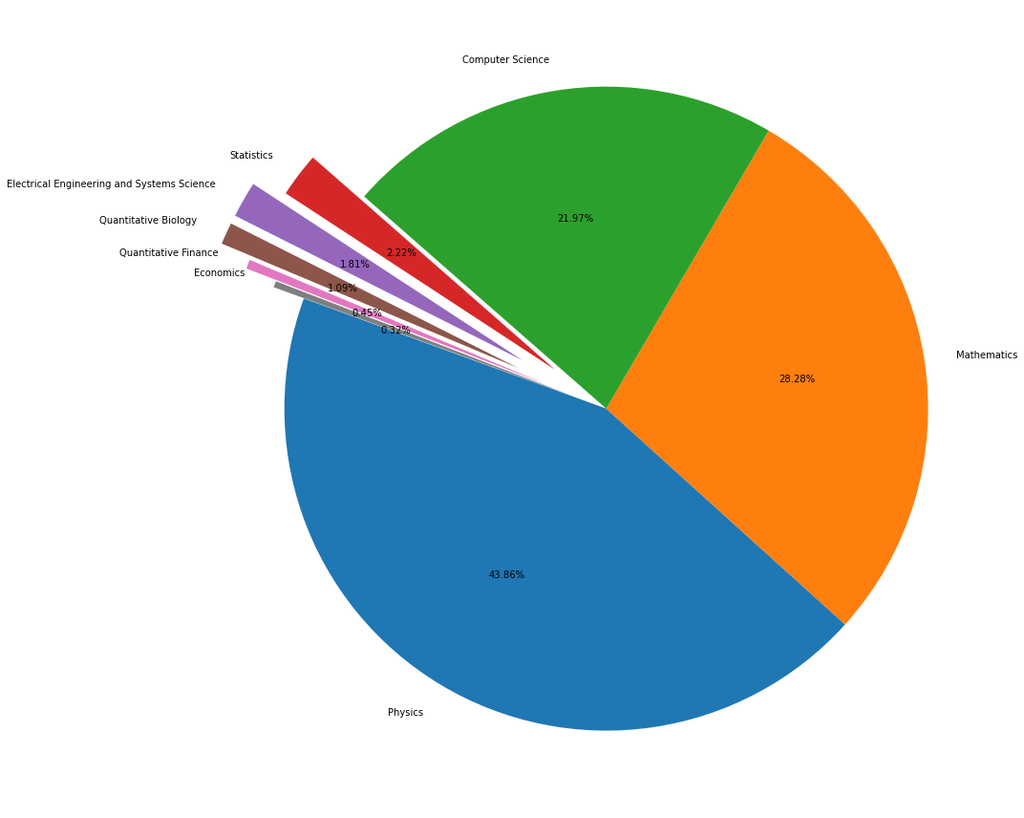

```python
# 主要使用matplotlib库
fig = plt.figure(figsize = (15, 12)) #设置图大小
explode = (0, 0, 0, 0.2, 0.3, 0.3, 0.2, 0.1)
plt.pie(_df["count"], labels = _df["group_name"], autopct = '%1.2f%%',\
       startangle=160, explode=explode)
plt.tight_layout()
plt.show()
```

> 额外任务统计各个子领域内2019年及以后的paper数量

```python
group_name="Computer Science"
cats = data.merge(df_taxonomy, on="categories")\
    .query("group_name == @group_name")

cats.groupby(["year", "category_name"])\
    .count().reset_index().pivot(index = 'category_name',\
                                 columns = "year", values = "id")

# 如果报错,很有可能是输入变量时输错了
```

| year category_name | 2019 | 2020 |
| --- | --- | --- |
| Artificial Intelligence | 558 | 757 |
| Computation and Language | 2153 | 2906 |
| Computational Complexity | 131 | 188 |
| Computational Engineering, Finance, and Science | 108 | 205 |
| Computational Geometry | 199 | 216 |
| Computer Science and Game Theory | 281 | 323 |
| Computer Vision and Pattern Recognition | 5559 | 6517 |
| Computers and Society | 346 | 564 |
| Cryptography and Security | 1067 | 1238 |
| Data Structures and Algorithms | 711 | 902 |
| Databases | 282 | 342 |
| Digital Libraries | 125 | 157 |
| Discrete Mathematics | 84 | 81 |
| Distributed, Parallel, and Cluster Computing | 715 | 774 |
| Emerging Technologies | 101 | 84 |
| Formal Languages and Automata Theory | 152 | 137 |
| General Literature | 5 | 5 |
| Graphics | 116 | 151 |
| Hardware Architecture | 95 | 159 |
| Human-Computer Interaction | 420 | 580 |
| Information Retrieval | 245 | 331 |
| Logic in Computer Science | 470 | 504 |
| Machine Learning | 177 | 538 |
| Mathematical Software | 27 | 45 |
| Multiagent Systems | 85 | 90 |
| Multimedia | 76 | 66 |
| Networking and Internet Architecture | 864 | 783 |
| Neural and Evolutionary Computing | 235 | 279 |
| Numerical Analysis | 40 | 11 |
| Operating Systems | 36 | 33 |
| Other Computer Science | 67 | 69 |
| Performance | 45 | 51 |
| Programming Languages | 268 | 294 |
| Robotics | 917 | 1298 |
| Social and Information Networks | 202 | 325 |
| Software Engineering | 659 | 804 |
| Sound | 7 | 4 |
| Symbolic Computation | 44 | 36 |
| Systems and Control | 415 | 133 |

## 学习收获

- 报了很多bug,知道自己代码能力不强
- 认识很多人,向大佬们致敬
- 试着使用markdown --- jupyter notebook里的markdown换个行还非得用br标签,刚开始感觉好麻烦